# Red_Wine_DataAnalysis

```
## red_df$quality: 3
##    Min. 1st Qu.  Median    Mean 3rd Qu.    Max.
##  0.9947  0.9961  0.9976  0.9975  0.9988  1.0008
## --------------------------------------------------------
## red_df$quality: 4
##    Min. 1st Qu.  Median    Mean 3rd Qu.    Max.
##  0.9934  0.9957  0.9965  0.9965  0.9974  1.0010
## --------------------------------------------------------
## red_df$quality: 5
##    Min. 1st Qu.  Median    Mean 3rd Qu.    Max.
##  0.9926  0.9962  0.9970  0.9971  0.9979  1.0031
## --------------------------------------------------------
## red_df$quality: 6
##    Min. 1st Qu.  Median    Mean 3rd Qu.    Max.
##  0.9901  0.9954  0.9966  0.9966  0.9979  1.0037
## --------------------------------------------------------
## red_df$quality: 7
##    Min. 1st Qu.  Median    Mean 3rd Qu.    Max.
##  0.9906  0.9948  0.9958  0.9961  0.9974  1.0032
## --------------------------------------------------------
## red_df$quality: 8
##    Min. 1st Qu.  Median    Mean 3rd Qu.    Max.
##  0.9908  0.9942  0.9949  0.9952  0.9972  0.9988
```

**five number summary of density for each quality of wine**

- Median density of wines is almost in the same range for all wine qualities.
- Wine with quality rating of 8 has the least maximum density.

```
## red_df$quality: 3
##    Min. 1st Qu.  Median    Mean 3rd Qu.    Max.
##  0.0000  0.0050  0.0350  0.1710  0.3275  0.6600
## --------------------------------------------------------
## red_df$quality: 4
##    Min. 1st Qu.  Median    Mean 3rd Qu.    Max.
##  0.0000  0.0300  0.0900  0.1742  0.2700  1.0000
## --------------------------------------------------------
## red_df$quality: 5
##    Min. 1st Qu.  Median    Mean 3rd Qu.    Max.
##  0.0000  0.0900  0.2300  0.2437  0.3600  0.7900
## --------------------------------------------------------
## red_df$quality: 6
##    Min. 1st Qu.  Median    Mean 3rd Qu.    Max.
##  0.0000  0.0900  0.2600  0.2738  0.4300  0.7800
## --------------------------------------------------------
## red_df$quality: 7
##    Min. 1st Qu.  Median    Mean 3rd Qu.    Max.
##  0.0000  0.3050  0.4000  0.3752  0.4900  0.7600
## --------------------------------------------------------
## red_df$quality: 8
##    Min. 1st Qu.  Median    Mean 3rd Qu.    Max.
##  0.0300  0.3025  0.4200  0.3911  0.5300  0.7200
```

**five number summary of citric acid for each quality of wine**

```
## red_df$quality: 3
##    Min. 1st Qu.  Median    Mean 3rd Qu.    Max.
##  0.4000  0.5125  0.5450  0.5700  0.6150  0.8600
## --------------------------------------------------------
## red_df$quality: 4
##    Min. 1st Qu.  Median    Mean 3rd Qu.    Max.
##  0.3300  0.4900  0.5600  0.5964  0.6000  2.0000
## --------------------------------------------------------
## red_df$quality: 5
##    Min. 1st Qu.  Median    Mean 3rd Qu.    Max.
##   0.370   0.530   0.580   0.621   0.660   1.980
## --------------------------------------------------------
## red_df$quality: 6
##    Min. 1st Qu.  Median    Mean 3rd Qu.    Max.
##  0.4000  0.5800  0.6400  0.6753  0.7500  1.9500
## --------------------------------------------------------
## red_df$quality: 7
##    Min. 1st Qu.  Median    Mean 3rd Qu.    Max.
##  0.3900  0.6500  0.7400  0.7413  0.8300  1.3600
## --------------------------------------------------------
## red_df$quality: 8
##    Min. 1st Qu.  Median    Mean 3rd Qu.    Max.
##  0.6300  0.6900  0.7400  0.7678  0.8200  1.1000
```

**five number summary of sulphates for each quality of wine**

- As the wine quality increases the median wine quality also increases.
- Wines with rating of 4 has the maximum sulphate content where as the wines with quality rating of 3 has the least sulphate content.

```
## red_df$quality: 3
##    Min. 1st Qu.  Median    Mean 3rd Qu.    Max.
##   3.160   3.312   3.390   3.398   3.495   3.630
## --------------------------------------------------------
## red_df$quality: 4
##    Min. 1st Qu.  Median    Mean 3rd Qu.    Max.
##   2.740   3.300   3.370   3.382   3.500   3.900
## --------------------------------------------------------
## red_df$quality: 5
##    Min. 1st Qu.  Median    Mean 3rd Qu.    Max.
##   2.880   3.200   3.300   3.305   3.400   3.740
## --------------------------------------------------------
## red_df$quality: 6
##    Min. 1st Qu.  Median    Mean 3rd Qu.    Max.
##   2.860   3.220   3.320   3.318   3.410   4.010
## --------------------------------------------------------
## red_df$quality: 7
##    Min. 1st Qu.  Median    Mean 3rd Qu.    Max.
##   2.920   3.200   3.280   3.291   3.380   3.780
## --------------------------------------------------------
## red_df$quality: 8
##    Min. 1st Qu.  Median    Mean 3rd Qu.    Max.
##   2.880   3.163   3.230   3.267   3.350   3.720
```

**five number summary of pH for each quality of wine**

- Median pH value of wines decreases as the wine quality increases.
- Maximum pH value is recorded for wine quality of 6.

```
## red_df$quality: 3
##    Min. 1st Qu.  Median    Mean 3rd Qu.    Max.
##   8.400   9.725   9.925   9.955  10.575  11.000
## --------------------------------------------------------
## red_df$quality: 4
##    Min. 1st Qu.  Median    Mean 3rd Qu.    Max.
##    9.00    9.60   10.00   10.27   11.00   13.10
## --------------------------------------------------------
## red_df$quality: 5
##    Min. 1st Qu.  Median    Mean 3rd Qu.    Max.
##     8.5     9.4     9.7     9.9    10.2    14.9
## --------------------------------------------------------
## red_df$quality: 6
##    Min. 1st Qu.  Median    Mean 3rd Qu.    Max.
##    8.40    9.80   10.50   10.63   11.30   14.00
## --------------------------------------------------------
## red_df$quality: 7
##    Min. 1st Qu.  Median    Mean 3rd Qu.    Max.
##    9.20   10.80   11.50   11.47   12.10   14.00
## --------------------------------------------------------
## red_df$quality: 8
##    Min. 1st Qu.  Median    Mean 3rd Qu.    Max.
##    9.80   11.32   12.15   12.09   12.88   14.00
```

**Five number summary for alcohol contents for each rating of wines**

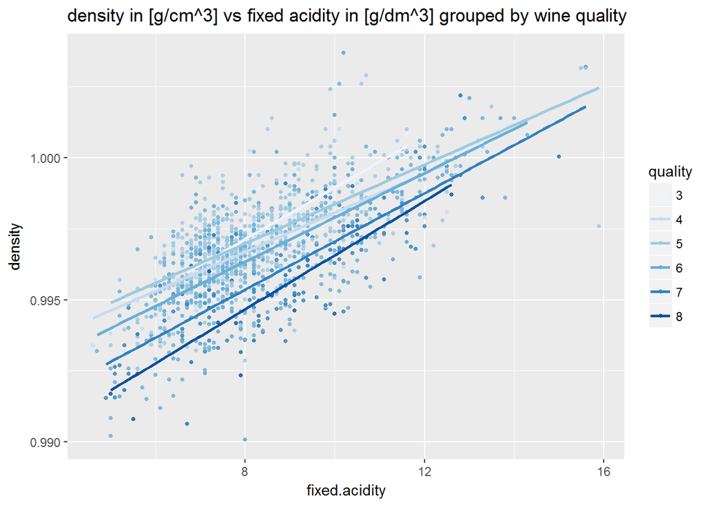

- As the fixed acidty increase in the wines the density of the wines also increases.
- Most of the wines with quality rating of 8 have low fixed acidity and low density.
- Wine with highest and lowestdensity have quality rating of 6.
- Wines with highest fixed acidity has a rating of 5 and lowest fixe acidty has a rating of 5

## 3.1 Talk about some of the relationships you observed in this part of the investigation. Were there features that strengthened each other in terms of looking at your feature (s) of interest?

The inverse relationshp between the pH and fixed acidity is very much visible across all categories of qualities of wines. Most of the high quality wines had higher fixed acidity levels.

## 3.2 Were there any interesting or surprising interactions between features?

Density and alchol had a negative relationship. When I had a regression line in that plot it seems that it is exactly bisecting the wines with quality ratings of 5 and below and wines with ratings of 6 and above. Most of the low quality wines(qines with ratings below 6) are present below the regression line which means they have average density and low in alcohol content. Whereas all the good quality wines are on top of the regression line which means that they have higher alcohol content and average to above average density.

# 4 Final Plots and Summary

## 4.1 Plot One

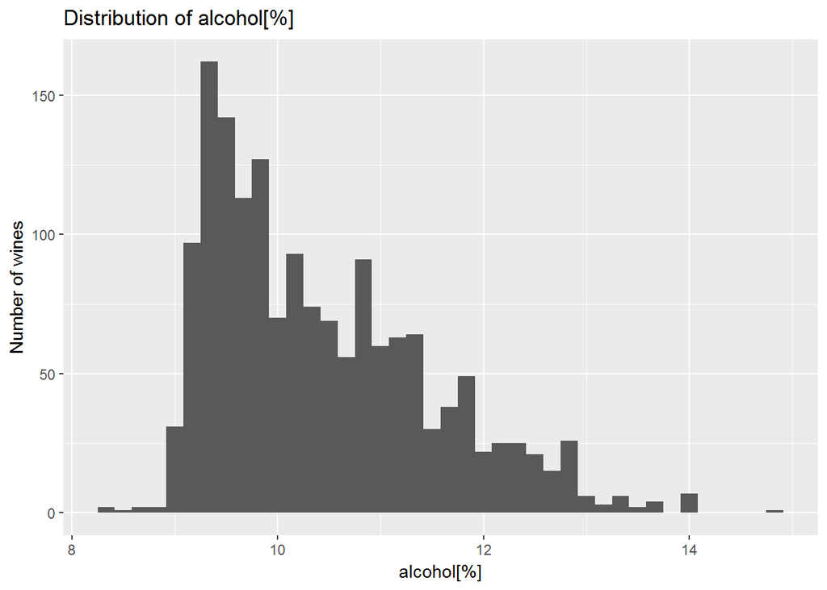

## 4.2 Plot Two

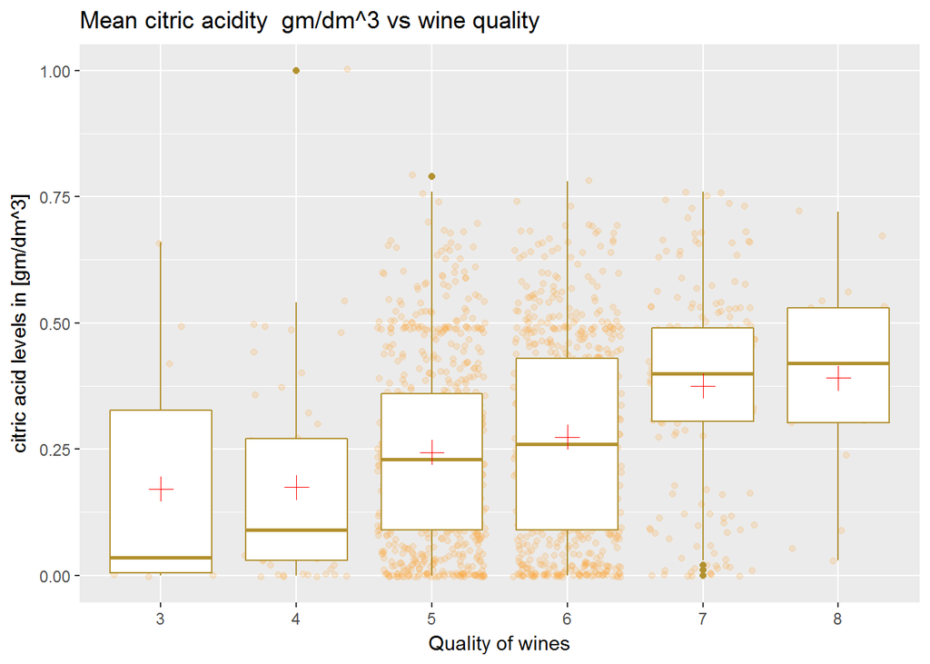

- This plot where I compare the effect of citirc acid content on the quality of wine and it seems it has profound effect on the wine quality.
- It can be seen that the mean citric acid content increases as the quality of wine increases.

## 4.3 Plot Three

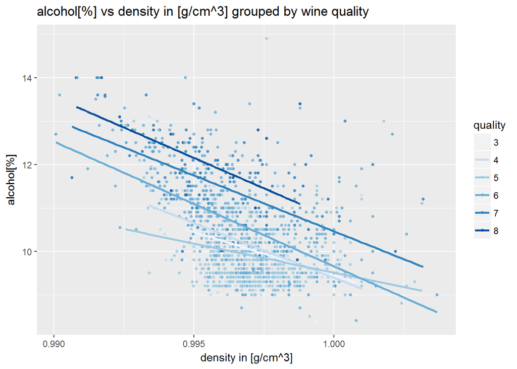

- I choose this graph for final plots because the way the regression line is separated for each of the wine qualities. It can be seen that regression line for wines with quality ratings of 6,7,8 are in parallel to each other. Topmost regression line is of wines with quality rating of 8 then followed by 7 then by 6.
- Most the wines with quality rating of 6 and above are above the regression line and wines with quality rating below 6 are below the regression line

# 5 Reflection

- The wines dataset has 1599 entries with 13 variables.
- I started my analysis by understanding the spread of each of the variable. I also checked if there are any outliers in wach of the variables by plotting box plots for each of the variables.
- I wanted to check what are the variables impacting the quality of wine. Initially I thought the alcohol content is the major factor influencing the wine quality.
- Higher the alcohol content better the rating of the wine. But as I started to explore the relationship between these two variables a bit more I found that there was a good correlation between these two variables. As the wine quality increases there is an increase in the alcohol conetent also. This relation had an exception only the wines with rating of 5 where there was a slight dip in the mean alcohol content.
- Surprisingly citric acid content had a good impact on the wine quality too. As the quality increased the mean citric acid content also increased and it was quite evident. This may be because it adds freshness to the wine and hence impacts the quality ratings.
- Then I started to look into other variables affecting the wine quality and I found that the sulphate content and pH also had a impact in determining the quality rating of wine.
- As the wine quality increased the mean pH value saw a dip. Mean Sulphate conetent was higher as the quality of wine was increasing. Although the slope was gradual but still there was an improvement as the quality of wine increased.
- The wine quality increases the density saw a dip. This might be because of the higher alcohol content as the wine quality increases.Volatile acidity also increased as the wine quality increased but it was stable for wines with quality ratings of 7 and 8.
- I created an linear model which takes into account alcohol content to predict the quality ratings. This model has a very low R-Squared value.
- Further I felt that a linear model is not very much suitable for this dataset as I am trying to predict a variable which is not continuous eventhough it has a numerical value it is more like a categorical variable.
- Hence a model like Logistic regression , K nearest nieghbour or Random forest would have been more suitable to predict the quality of wines.

# 6 Limitations of dataset

- Although the dataset has good number of variables for predicting the wine quality. It lacks a bit in number of observations.
- Also, most of the wines have a rating of 5 and 6. There are very few wines at the lower and higher quality ratings. This hinders drawing solid inferences about what are the differentiating factors which help in getting higher or lower quality ratings.
- All the wines realted to thsi dataset are for the wines of variants of the Portuguese “Vinho Verde” wine. It would be better if we had other red wines also included in the dataset in that way I could have analysed a bit more for different types of redwines and how the variables affect the wine quality of the wines.
- It would have been better if both red and white wine were in the same dataset ,so that I could have analysed the impact of different variables on the wine quality for each red and white wine.